# 交接文档

王超

2017-03-09

我的工作包含以下几个方面：

- 组合优化
- IC计算
- 行业/市值中性
- Risk Model

## 组合优化

组合优化的参考文献在 `192.168.1.100\public\cwnag\opt` 中，code是 `/opt/GFTCacheServer/RScripts/Portfolioop.R`。 主要用到的 package 是 `PortfolioAnalytics`， 对于求解最优解的算法，主要是 `glpk`，`quadprod`和 `DEoptim`。 相应的APP为 `64C9DC1C96FD4A0693305C87E905E039`， 在APP界面中，需要输入的参数如图所示：

[figure not shown]

在`ExpectedReturn/CovarianceMatrix` 的 `...` 中可以选择不同的计算方法，选中任意一个后，需要首先配置基金组合（可以多选，推荐选择一个股票型一个债券型） 在因子模型中还需要选择因子收益的计算模型（包含`MA5`和`ARIMA`两种模型），选好之后点击确定。

`GroupConstraint`是为了设置不同类型基金的权重，选择退休年限限制时必须确保基金池中包含债券型基金和股票型基金。 在基金组合的选项中，可以选择一级分类的资产类别，也可以根据自己的基金池自定义基金类型。在右下角配置好权重之后点击绿色的按钮上传，然后点击确定。

风险厌恶是目标函数 $\mu - \lambda*\sigma^{2}$ 中的 $\lambda$, 用来调节目标函数的风险厌恶程度，当 $\lambda == 0$ 时，优化结果为收益最大， 当 $\lambda -> \infty$ 时， 优化结果为风险最小。

权重上下限是对于每个基金权重的限制，确保不会出现单一基金持仓过重的情况。个数上限是最终组合中最大基金数目的限制。

上述参数配置好之后点击执行优化，过一会会出现优化结果。

## IC计算

参考文献为 华泰单因子测试之估值类因子。 因子的 IC 值是指因子在第 T 期的暴露度与 T+1 期的股票收益的相关系数，即

$IC^{T}_d = corr(R^{T+n},d^{T})$

其中，$IC^{T}_d$代表因子$d$在第$T$期的$IC$值， $R^{T+n}$代表所有个股在第$T+1$期的收益率，$d^{T}$代表所有个股第$T$期在因子$d$上的暴露。注意，我们目前用的因子和收益率都做了`rank`处理。目前$n$的取值为1-12，每期的时间长度也可以通过`winSize`调整，可以用来检测因子的稳定性。

评价因子的方法包括：

- IC值序列的均值大小
- IC值序列的标准差
- IR比率
- IC累积值曲线
- IC值序列大于零占比

在计算IC的FR中，同样包括了单因子`factor return`的计算，通过`linear regression`对于因子和收益进行截面回归，剔除了行业的影响，得到因子收益的序列。

## 行业/市值中性

参考文献为 华泰单因子测试之估值类因子。 原理同研报中的`单因子分层法`， 行业中性是在每个一级行业内部对所有个股按因子大小进行排序，每个行业内均分成 N 个分层组合。如下图所示，黄色方块代表各行业内个股初始权重，采用等权的方式。每个行业的权重按照基准中行业权重配置。 市值中性原理相同。

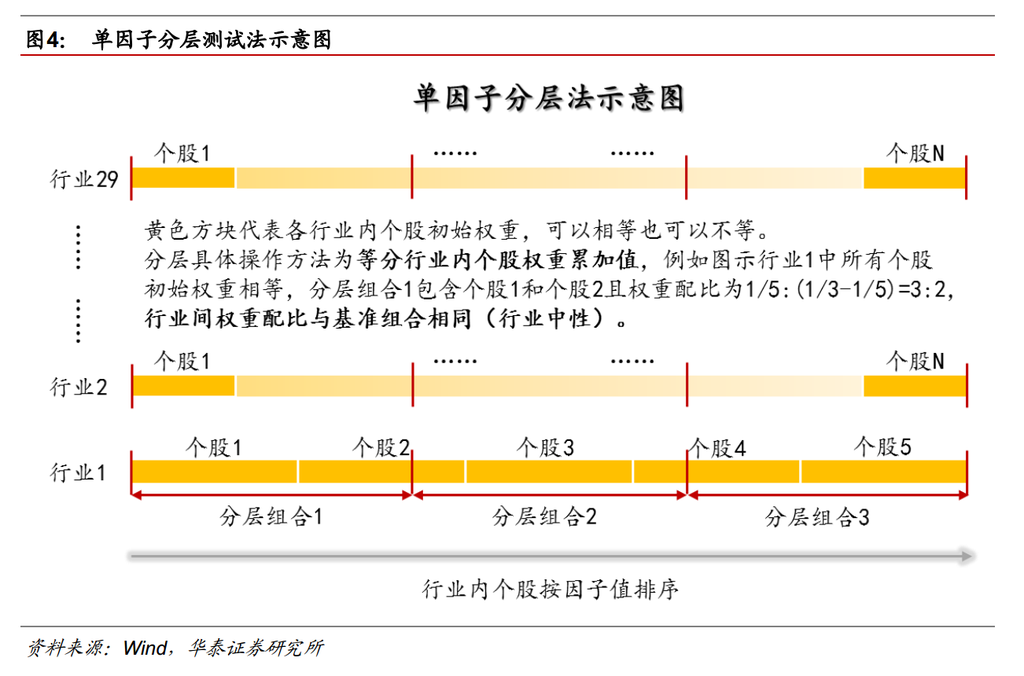

## Risk Model

Risk Model 的参考文献为 [ClariFI Online Help](http://q.gftchina.com:12860/ClariFI_Online_Help)， 在GS上的实现过程参考下图：

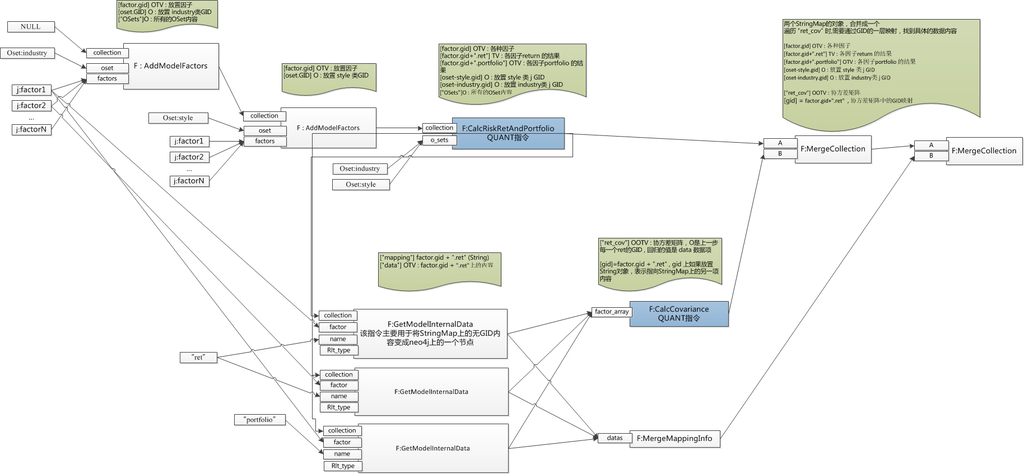

首先将行业因子加入Stringmap，然后再将风格因子加入Stringmap，通过MFM计算出每个因子的因子收益和标的的特殊风险，然后计算出因子收益之间的协方差矩阵。具体的指令在`106`上的`/RScript/RiskModel/calcFactorReturn_SpecificRisk.R`和`/RScript/RiskModel/calcRiskCovNew.R`，参考GS上搭成的节点`A9EF8B3B76E44099E43BBCC089A9F7EA`

有了Risk Model之后，可以用来计算策略的风险报告，具体算法参考[ClariFI](http://q.gftchina.com:12860/Portfolio_attribution_process)的计算公式， 相应的指令为`/RScript/RiskModel/calcRiskAttribution.R`